# Test and Score Wed Apr 08 20, 11:40:16

## Settings

**Sampling type:** Stratified 2-fold Cross validation  
**Target class:** Average over classes

## Scores

| Model | Train time [s] | Test time [s] | AUC | CA | F1 | Precision | Recall | LogLoss | Specificity |
| --- | --- | --- | --- | --- | --- | --- | --- | --- | --- |
| Tree | 0.230 | 0.001 | 0.8236914600550964 | 0.7878787878787878 | 0.7878787878787878 | 0.7878787878787878 | 0.7878787878787878 | 5.787969422510566 | 0.7878787878787878 |
| AdaBoost | 0.535 | 0.472 | 0.8484848484848486 | 0.8484848484848485 | 0.8484848484848486 | 0.8484848484848485 | 0.8484848484848485 | 5.23314793862283 | 0.8484848484848485 |
| kNN | 0.590 | 0.404 | 0.9545454545454545 | 0.9090909090909091 | 0.9083333333333333 | 0.923076923076923 | 0.9090909090909091 | 1.6612424949643325 | 0.9090909090909092 |
| Neural Network | 1.787 | 0.688 | 0.9944903581267218 | 0.9545454545454546 | 0.9544513457556936 | 0.9583333333333334 | 0.9545454545454546 | 0.22421584479360004 | 0.9545454545454546 |
| Logistic Regression | 0.495 | 0.396 | 1.0 | 0.9696969696969697 | 0.9696691176470589 | 0.9714285714285714 | 0.9696969696969697 | 0.051728621950555 | 0.9696969696969697 |
| SVM | 1.518 | 0.675 | 1.0 | 0.9848484848484849 | 0.9848450057405281 | 0.9852941176470589 | 0.9848484848484849 | 0.059606413688531486 | 0.9848484848484849 |

# Test and Score Wed Apr 08 20, 11:41:19

## Settings

**Sampling type:** Stratified 3-fold Cross validation  
**Target class:** Average over classes

## Scores

| Model | Train time [s] | Test time [s] | AUC | CA | F1 | Precision | Recall | LogLoss | Specificity |
| --- | --- | --- | --- | --- | --- | --- | --- | --- | --- |
| AdaBoost | 0.861 | 0.621 | 0.8636363636363638 | 0.8636363636363636 | 0.8636050516647532 | 0.863970588235294 | 0.8636363636363636 | 4.709833144760548 | 0.8636363636363636 |
| Tree | 0.308 | 0.000 | 0.9063360881542699 | 0.8787878787878788 | 0.8783410138248849 | 0.8844361602982292 | 0.8787878787878788 | 1.3458182590815728 | 0.8787878787878789 |
| kNN | 0.900 | 0.554 | 0.9696969696969697 | 0.9090909090909091 | 0.9083333333333333 | 0.923076923076923 | 0.9090909090909091 | 1.1392648987953056 | 0.9090909090909092 |
| Neural Network | 2.910 | 1.088 | 1.0 | 0.9696969696969697 | 0.9696691176470589 | 0.9714285714285714 | 0.9696969696969697 | 0.05582811725452377 | 0.9696969696969697 |
| Logistic Regression | 1.017 | 0.628 | 1.0 | 1.0 | 1.0 | 1.0 | 1.0 | 0.03345753379614641 | 1.0 |
| SVM | 2.436 | 0.926 | 1.0 | 1.0 | 1.0 | 1.0 | 1.0 | 0.04596734855452094 | 1.0 |

# Test and Score Wed Apr 08 20, 11:42:22

## Settings

**Sampling type:** Stratified 5-fold Cross validation  
**Target class:** Average over classes

## Scores

| Model | Train time [s] | Test time [s] | AUC | CA | F1 | Precision | Recall | LogLoss | Specificity |
| --- | --- | --- | --- | --- | --- | --- | --- | --- | --- |
| Tree | 0.632 | 0.003 | 0.8572084481175392 | 0.8333333333333334 | 0.8329882677708765 | 0.8361111111111111 | 0.8333333333333334 | 3.8686694773972814 | 0.8333333333333333 |
| AdaBoost | 1.453 | 0.910 | 0.8484848484848485 | 0.8484848484848485 | 0.847926267281106 | 0.853681267474371 | 0.8484848484848485 | 5.233147938622831 | 0.8484848484848484 |
| kNN | 1.524 | 0.848 | 0.9696969696969697 | 0.9242424242424242 | 0.9238051258369891 | 0.9342105263157895 | 0.9242424242424242 | 1.1271662973374605 | 0.9242424242424243 |
| Neural Network | 5.119 | 1.885 | 1.0 | 0.9696969696969697 | 0.9696691176470589 | 0.9714285714285714 | 0.9696969696969697 | 0.0621779223059567 | 0.9696969696969697 |
| Logistic Regression | 1.457 | 0.856 | 1.0 | 1.0 | 1.0 | 1.0 | 1.0 | 0.03263332695190502 | 1.0 |
| SVM | 4.276 | 1.684 | 1.0 | 1.0 | 1.0 | 1.0 | 1.0 | 0.040386752127315094 | 1.0 |

# Test and Score Wed Apr 08 20, 11:44:09

## Settings

**Sampling type:** Stratified 10-fold Cross validation  
**Target class:** Average over classes

## Scores

| Model | Train time [s] | Test time [s] | AUC | CA | F1 | Precision | Recall | LogLoss | Specificity |
| --- | --- | --- | --- | --- | --- | --- | --- | --- | --- |
| Tree | 1.550 | 0.000 | 0.8971533516988063 | 0.8939393939393939 | 0.893719806763285 | 0.8972222222222223 | 0.8939393939393939 | 3.1940624633643493 | 0.893939393939394 |
| AdaBoost | 3.245 | 1.502 | 0.9090909090909091 | 0.9090909090909091 | 0.9090909090909091 | 0.9090909090909091 | 0.9090909090909091 | 3.139888763173699 | 0.9090909090909091 |
| kNN | 2.572 | 2.409 | 0.9848484848484849 | 0.9393939393939394 | 0.9391705069124423 | 0.9459459459459459 | 0.9393939393939394 | 0.6072324663738776 | 0.9393939393939394 |
| Neural Network | 11.683 | 4.186 | 1.0 | 0.9696969696969697 | 0.9696691176470589 | 0.9714285714285714 | 0.9696969696969697 | 0.060053930739891834 | 0.9696969696969697 |
| Logistic Regression | 2.821 | 2.306 | 1.0 | 1.0 | 1.0 | 1.0 | 1.0 | 0.026424532787748416 | 1.0 |
| SVM | 8.997 | 2.932 | 1.0 | 1.0 | 1.0 | 1.0 | 1.0 | 0.03381480901879534 | 1.0 |

# Test and Score Wed Apr 08 20, 11:46:24

## Settings

**Sampling type:** Stratified 20-fold Cross validation  
**Target class:** Average over classes

## Scores

| Model | Train time [s] | Test time [s] | AUC | CA | F1 | Precision | Recall | LogLoss | Specificity |
| --- | --- | --- | --- | --- | --- | --- | --- | --- | --- |
| Tree | 3.699 | 0.002 | 0.8645546372819101 | 0.8484848484848485 | 0.847926267281106 | 0.853681267474371 | 0.8484848484848485 | 4.293031097475059 | 0.8484848484848484 |
| AdaBoost | 6.748 | 4.063 | 0.8636363636363638 | 0.8636363636363636 | 0.8636050516647532 | 0.863970588235294 | 0.8636363636363636 | 4.709833144760547 | 0.8636363636363636 |
| kNN | 7.074 | 4.405 | 0.9848484848484849 | 0.9242424242424242 | 0.9238051258369891 | 0.9342105263157895 | 0.9242424242424242 | 0.6133758771027891 | 0.9242424242424243 |
| Neural Network | 24.888 | 9.660 | 1.0 | 0.9848484848484849 | 0.9848450057405281 | 0.9852941176470589 | 0.9848484848484849 | 0.05690223217284387 | 0.9848484848484849 |
| Logistic Regression | 7.460 | 4.160 | 1.0 | 1.0 | 1.0 | 1.0 | 1.0 | 0.02427353930247442 | 1.0 |
| SVM | 20.625 | 7.691 | 1.0 | 1.0 | 1.0 | 1.0 | 1.0 | 0.032354789458725934 | 1.0 |

# Test and Score Wed Apr 08 20, 11:57:16

## Settings

**Sampling type:** Stratified 2-fold Cross validation  
**Target class:** Abortion

## Scores

| Model | Train time [s] | Test time [s] | AUC | CA | F1 | Precision | Recall | LogLoss | Specificity |
| --- | --- | --- | --- | --- | --- | --- | --- | --- | --- |
| Tree | 0.217 | 0.000 | 0.8272058823529411 | 0.7878787878787878 | 0.7878787878787878 | 0.7878787878787878 | 0.7878787878787878 | 5.787969422510566 | 0.7878787878787878 |
| kNN | 0.569 | 0.424 | 0.9558823529411764 | 0.9090909090909091 | 0.9 | 1.0 | 0.8181818181818182 | 1.6612424949643325 | 1.0 |
| AdaBoost | 0.539 | 0.392 | 0.8520220588235293 | 0.8484848484848485 | 0.8484848484848486 | 0.8484848484848485 | 0.8484848484848485 | 5.23314793862283 | 0.8484848484848485 |
| Neural Network | 1.745 | 0.775 | 0.9981617647058824 | 0.9545454545454546 | 0.9523809523809523 | 1.0 | 0.9090909090909091 | 0.22421584479360004 | 1.0 |
| Logistic Regression | 0.506 | 0.410 | 1.0 | 0.9696969696969697 | 0.96875 | 1.0 | 0.9393939393939394 | 0.051728621950555 | 1.0 |
| SVM | 1.433 | 0.762 | 1.0 | 0.9848484848484849 | 0.9846153846153846 | 1.0 | 0.9696969696969697 | 0.07060232914901664 | 1.0 |

# Test and Score Wed Apr 08 20, 11:59:51

## Settings

**Sampling type:** Stratified 3-fold Cross validation  
**Target class:** Abortion

## Scores

| Model | Train time [s] | Test time [s] | AUC | CA | F1 | Precision | Recall | LogLoss | Specificity |
| --- | --- | --- | --- | --- | --- | --- | --- | --- | --- |
| kNN | 1.108 | 0.471 | 0.9696969696969697 | 0.9090909090909091 | 0.9 | 1.0 | 0.8181818181818182 | 1.1392648987953056 | 1.0 |
| Tree | 0.307 | 0.000 | 0.8787878787878788 | 0.8787878787878788 | 0.8709677419354839 | 0.9310344827586207 | 0.8181818181818182 | 1.3458182590815728 | 0.9393939393939394 |
| AdaBoost | 0.877 | 0.534 | 0.8636363636363636 | 0.8636363636363636 | 0.8615384615384615 | 0.875 | 0.8484848484848485 | 4.709833144760548 | 0.8787878787878788 |
| Neural Network | 2.799 | 1.195 | 1.0 | 0.9696969696969697 | 0.96875 | 1.0 | 0.9393939393939394 | 0.05582811725452377 | 1.0 |
| Logistic Regression | 1.110 | 0.450 | 1.0 | 1.0 | 1.0 | 1.0 | 1.0 | 0.03345753379614641 | 1.0 |
| SVM | 2.234 | 1.120 | 1.0 | 1.0 | 1.0 | 1.0 | 1.0 | 0.04652940000600144 | 1.0 |

# Test and Score Wed Apr 08 20, 12:00:58

## Settings

**Sampling type:** Stratified 5-fold Cross validation  
**Target class:** Abortion

## Scores

| Model | Train time [s] | Test time [s] | AUC | CA | F1 | Precision | Recall | LogLoss | Specificity |
| --- | --- | --- | --- | --- | --- | --- | --- | --- | --- |
| Tree | 0.641 | 0.000 | 0.8380952380952381 | 0.8333333333333334 | 0.8253968253968254 | 0.8666666666666667 | 0.7878787878787878 | 3.8686694773972814 | 0.8787878787878788 |
| AdaBoost | 1.429 | 0.949 | 0.8523809523809524 | 0.8484848484848485 | 0.8387096774193549 | 0.896551724137931 | 0.7878787878787878 | 5.233147938622831 | 0.9090909090909091 |
| kNN | 1.499 | 0.974 | 0.9714285714285715 | 0.9242424242424242 | 0.9180327868852458 | 1.0 | 0.8484848484848485 | 1.1271662973374605 | 1.0 |
| Neural Network | 4.955 | 2.132 | 1.0 | 0.9696969696969697 | 0.96875 | 1.0 | 0.9393939393939394 | 0.0621779223059567 | 1.0 |
| Logistic Regression | 1.335 | 1.048 | 1.0 | 1.0 | 1.0 | 1.0 | 1.0 | 0.03263332695190502 | 1.0 |
| SVM | 4.079 | 1.831 | 1.0 | 1.0 | 1.0 | 1.0 | 1.0 | 0.045580341298159834 | 1.0 |

# Test and Score Wed Apr 08 20, 12:02:22

## Settings

**Sampling type:** Stratified 10-fold Cross validation  
**Target class:** Abortion

## Scores

| Model | Train time [s] | Test time [s] | AUC | CA | F1 | Precision | Recall | LogLoss | Specificity |
| --- | --- | --- | --- | --- | --- | --- | --- | --- | --- |
| Tree | 1.496 | 0.001 | 0.8875000000000002 | 0.8939393939393939 | 0.888888888888889 | 0.9333333333333333 | 0.8484848484848485 | 3.1940624633643493 | 0.9393939393939394 |
| kNN | 3.012 | 1.936 | 0.9875 | 0.9393939393939394 | 0.9354838709677419 | 1.0 | 0.8787878787878788 | 0.6072324663738776 | 1.0 |
| AdaBoost | 3.005 | 1.474 | 0.9041666666666666 | 0.9090909090909091 | 0.9090909090909091 | 0.9090909090909091 | 0.9090909090909091 | 3.139888763173699 | 0.9090909090909091 |
| Neural Network | 10.542 | 3.511 | 1.0 | 0.9696969696969697 | 0.96875 | 1.0 | 0.9393939393939394 | 0.060053930739891834 | 1.0 |
| Logistic Regression | 3.204 | 1.658 | 1.0 | 1.0 | 1.0 | 1.0 | 1.0 | 0.026424532787748416 | 1.0 |
| SVM | 8.685 | 3.054 | 1.0 | 1.0 | 1.0 | 1.0 | 1.0 | 0.03311149360416417 | 1.0 |

# Test and Score Wed Apr 08 20, 12:04:13

## Settings

**Sampling type:** Stratified 20-fold Cross validation  
**Target class:** Abortion

## Scores

| Model | Train time [s] | Test time [s] | AUC | CA | F1 | Precision | Recall | LogLoss | Specificity |
| --- | --- | --- | --- | --- | --- | --- | --- | --- | --- |
| Tree | 2.963 | 0.002 | 0.8625 | 0.8484848484848485 | 0.8387096774193549 | 0.896551724137931 | 0.7878787878787878 | 4.293031097475059 | 0.9090909090909091 |
| kNN | 6.061 | 3.934 | 0.9875 | 0.9242424242424242 | 0.9180327868852458 | 1.0 | 0.8484848484848485 | 0.6133758771027891 | 1.0 |
| AdaBoost | 6.513 | 3.026 | 0.8875 | 0.8636363636363636 | 0.8615384615384615 | 0.875 | 0.8484848484848485 | 4.709833144760547 | 0.8787878787878788 |
| Neural Network | 21.118 | 7.746 | 1.0 | 0.9848484848484849 | 0.9846153846153846 | 1.0 | 0.9696969696969697 | 0.05690223217284387 | 1.0 |
| Logistic Regression | 6.931 | 3.563 | 1.0 | 1.0 | 1.0 | 1.0 | 1.0 | 0.02427353930247442 | 1.0 |
| SVM | 17.518 | 6.116 | 1.0 | 1.0 | 1.0 | 1.0 | 1.0 | 0.03209750960257557 | 1.0 |

# Test and Score Wed Apr 08 20, 12:05:52

## Settings

**Sampling type:** Stratified 2-fold Cross validation  
**Target class:** No abortion

## Scores

| Model | Train time [s] | Test time [s] | AUC | CA | F1 | Precision | Recall | LogLoss | Specificity |
| --- | --- | --- | --- | --- | --- | --- | --- | --- | --- |
| Tree | 0.239 | 0.000 | 0.8272058823529411 | 0.7878787878787878 | 0.7878787878787878 | 0.7878787878787878 | 0.7878787878787878 | 5.787969422510566 | 0.7878787878787878 |
| AdaBoost | 0.557 | 0.300 | 0.8520220588235294 | 0.8484848484848485 | 0.8484848484848486 | 0.8484848484848485 | 0.8484848484848485 | 5.23314793862283 | 0.8484848484848485 |
| Logistic Regression | 0.574 | 0.401 | 1.0 | 0.9696969696969697 | 0.9705882352941178 | 0.9428571428571428 | 1.0 | 0.051728621950555 | 0.9393939393939394 |
| kNN | 0.601 | 0.415 | 0.9558823529411764 | 0.9090909090909091 | 0.9166666666666666 | 0.8461538461538461 | 1.0 | 1.6612424949643325 | 0.8181818181818182 |
| SVM | 1.570 | 0.776 | 1.0 | 0.9848484848484849 | 0.9850746268656717 | 0.9705882352941178 | 1.0 | 0.06355978536637015 | 0.9696969696969697 |
| Neural Network | 1.856 | 0.894 | 0.9981617647058824 | 0.9545454545454546 | 0.9565217391304348 | 0.9166666666666666 | 1.0 | 0.22421584479360004 | 0.9090909090909091 |

# Test and Score Wed Apr 08 20, 12:06:39

## Settings

**Sampling type:** Stratified 3-fold Cross validation  
**Target class:** No abortion

## Scores

| Model | Train time [s] | Test time [s] | AUC | CA | F1 | Precision | Recall | LogLoss | Specificity |
| --- | --- | --- | --- | --- | --- | --- | --- | --- | --- |
| AdaBoost | 0.785 | 0.635 | 0.8636363636363636 | 0.8636363636363636 | 0.8656716417910447 | 0.8529411764705882 | 0.8787878787878788 | 4.709833144760548 | 0.8484848484848485 |
| Tree | 0.304 | 0.000 | 0.8787878787878789 | 0.8787878787878788 | 0.8857142857142858 | 0.8378378378378378 | 0.9393939393939394 | 1.3458182590815728 | 0.8181818181818182 |
| Logistic Regression | 0.768 | 0.750 | 1.0 | 1.0 | 1.0 | 1.0 | 1.0 | 0.03345753379614641 | 1.0 |
| kNN | 0.895 | 0.674 | 0.9696969696969697 | 0.9090909090909091 | 0.9166666666666666 | 0.8461538461538461 | 1.0 | 1.1392648987953056 | 0.8181818181818182 |
| SVM | 2.230 | 1.137 | 1.0 | 1.0 | 1.0 | 1.0 | 1.0 | 0.044597793935498106 | 1.0 |
| Neural Network | 2.767 | 1.248 | 1.0 | 0.9696969696969697 | 0.9705882352941178 | 0.9428571428571428 | 1.0 | 0.05582811725452377 | 0.9393939393939394 |

# Test and Score Wed Apr 08 20, 12:07:21

## Settings

**Sampling type:** Stratified 5-fold Cross validation  
**Target class:** No abortion

## Scores

| Model | Train time [s] | Test time [s] | AUC | CA | F1 | Precision | Recall | LogLoss | Specificity |
| --- | --- | --- | --- | --- | --- | --- | --- | --- | --- |
| Tree | 0.643 | 0.000 | 0.8380952380952381 | 0.8333333333333334 | 0.8405797101449276 | 0.8055555555555556 | 0.8787878787878788 | 3.8686694773972814 | 0.7878787878787878 |
| AdaBoost | 1.420 | 1.110 | 0.8523809523809524 | 0.8484848484848485 | 0.8571428571428571 | 0.8108108108108109 | 0.9090909090909091 | 5.233147938622831 | 0.7878787878787878 |
| Logistic Regression | 1.478 | 1.024 | 1.0 | 1.0 | 1.0 | 1.0 | 1.0 | 0.03263332695190502 | 1.0 |
| kNN | 1.417 | 0.972 | 0.9714285714285715 | 0.9242424242424242 | 0.9295774647887324 | 0.868421052631579 | 1.0 | 1.1271662973374605 | 0.8484848484848485 |
| SVM | 4.183 | 1.695 | 1.0 | 1.0 | 1.0 | 1.0 | 1.0 | 0.04018453628722625 | 1.0 |
| Neural Network | 4.984 | 1.854 | 1.0 | 0.9696969696969697 | 0.9705882352941178 | 0.9428571428571428 | 1.0 | 0.0621779223059567 | 0.9393939393939394 |

# Test and Score Wed Apr 08 20, 12:08:29

## Settings

**Sampling type:** Stratified 10-fold Cross validation  
**Target class:** No abortion

## Scores

| Model | Train time [s] | Test time [s] | AUC | CA | F1 | Precision | Recall | LogLoss | Specificity |
| --- | --- | --- | --- | --- | --- | --- | --- | --- | --- |
| AdaBoost | 2.954 | 1.550 | 0.9041666666666666 | 0.9090909090909091 | 0.9090909090909091 | 0.9090909090909091 | 0.9090909090909091 | 3.139888763173699 | 0.9090909090909091 |
| Tree | 1.504 | 0.001 | 0.8875000000000002 | 0.8939393939393939 | 0.8985507246376813 | 0.8611111111111112 | 0.9393939393939394 | 3.1940624633643493 | 0.8484848484848485 |
| Logistic Regression | 3.145 | 1.654 | 1.0 | 1.0 | 1.0 | 1.0 | 1.0 | 0.026424532787748416 | 1.0 |
| kNN | 2.993 | 1.929 | 0.9875 | 0.9393939393939394 | 0.9428571428571428 | 0.8918918918918919 | 1.0 | 0.6072324663738776 | 0.8787878787878788 |
| SVM | 8.690 | 3.089 | 1.0 | 1.0 | 1.0 | 1.0 | 1.0 | 0.03433441628605249 | 1.0 |
| Neural Network | 10.343 | 3.723 | 1.0 | 0.9696969696969697 | 0.9705882352941178 | 0.9428571428571428 | 1.0 | 0.060053930739891834 | 0.9393939393939394 |

# Test and Score Wed Apr 08 20, 12:10:26

## Settings

**Sampling type:** Stratified 20-fold Cross validation  
**Target class:** No abortion

## Scores

| Model | Train time [s] | Test time [s] | AUC | CA | F1 | Precision | Recall | LogLoss | Specificity |
| --- | --- | --- | --- | --- | --- | --- | --- | --- | --- |
| AdaBoost | 6.814 | 3.019 | 0.8875 | 0.8636363636363636 | 0.8656716417910447 | 0.8529411764705882 | 0.8787878787878788 | 4.709833144760547 | 0.8484848484848485 |
| Tree | 3.021 | 0.002 | 0.8625 | 0.8484848484848485 | 0.8571428571428571 | 0.8108108108108109 | 0.9090909090909091 | 4.293031097475059 | 0.7878787878787878 |
| Logistic Regression | 7.036 | 3.633 | 1.0 | 1.0 | 1.0 | 1.0 | 1.0 | 0.02427353930247442 | 1.0 |
| kNN | 6.204 | 3.974 | 0.9875 | 0.9242424242424242 | 0.9295774647887324 | 0.868421052631579 | 1.0 | 0.6133758771027891 | 0.8484848484848485 |
| SVM | 18.039 | 6.045 | 1.0 | 1.0 | 1.0 | 1.0 | 1.0 | 0.032639654108216835 | 1.0 |
| Neural Network | 21.653 | 7.557 | 1.0 | 0.9848484848484849 | 0.9850746268656717 | 0.9705882352941178 | 1.0 | 0.05690223217284387 | 0.9696969696969697 |

# ROC Analysis Wed Apr 08 20, 12:41:27

**Target class:** Abortion  
**Costs:** FP = 500, FN = 500  
**Target probability:** 50.0 %

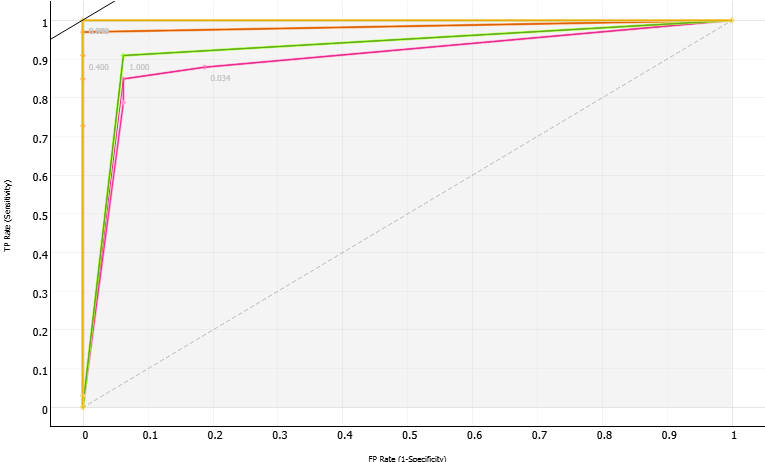

Logistic RegressionkNNSVMTreeAdaBoostNeural Network

# ROC Analysis Wed Apr 08 20, 12:41:48

**Target class:** No abortion  
**Costs:** FP = 500, FN = 500  
**Target probability:** 50.0 %

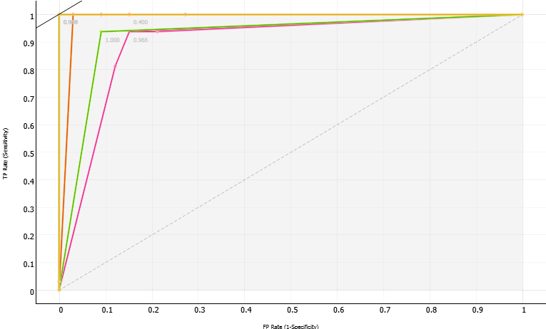

Logistic RegressionkNNSVMTreeAdaBoostNeural Network

# ROC Analysis Wed Apr 08 20, 12:43:45

**Target class:** No abortion  
**Costs:** FP = 500, FN = 500  
**Target probability:** 50.0 %

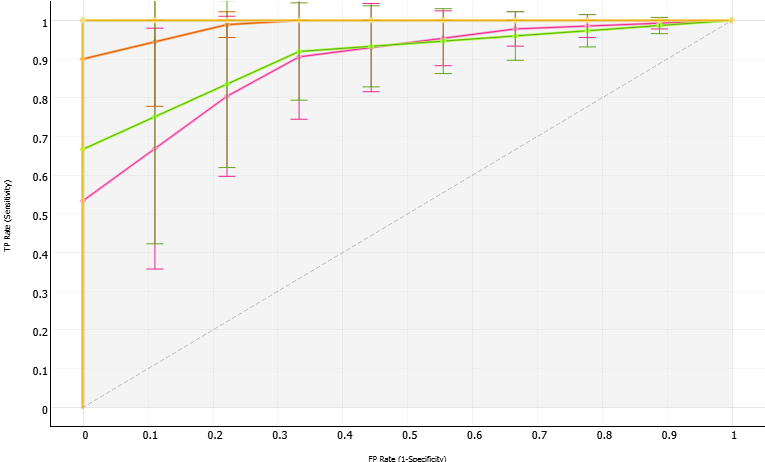

Logistic RegressionkNNSVMTreeAdaBoostNeural Network

# Confusion Matrix Wed Apr 08 20, 12:45:09

## Confusion matrix for Logistic Regression (showing proportion of predicted)

|  |  | Predicted |  |  |
| --- | --- | --- | --- | --- |
|  |  | Abortion | No abortion | ∑ |
| Actual | Abortion | 100.0 % | 0.0 % | 33 |
|  | No abortion | 0.0 % | 100.0 % | 33 |
|  | ∑ | 33 | 33 | 66 |

# Confusion Matrix Wed Apr 08 20, 12:47:26

## Confusion matrix for Logistic Regression (showing proportion of predicted)

|  |  | Predicted |  |  |
| --- | --- | --- | --- | --- |
|  |  | Abortion | No abortion | ∑ |
| Actual | Abortion | 100.0 % | 0.0 % | 33 |
|  | No abortion | 0.0 % | 100.0 % | 33 |
|  | ∑ | 33 | 33 | 66 |

# Confusion Matrix Wed Apr 08 20, 12:47:45

## Confusion matrix for kNN (showing proportion of predicted)

|  |  | Predicted |  |  |
| --- | --- | --- | --- | --- |
|  |  | Abortion | No abortion | ∑ |
| Actual | Abortion | 100.0 % | 10.8 % | 33 |
|  | No abortion | 0.0 % | 89.2 % | 33 |
|  | ∑ | 29 | 37 | 66 |

# Confusion Matrix Wed Apr 08 20, 12:48:07

## Confusion matrix for SVM (showing proportion of predicted)

|  |  | Predicted |  |  |
| --- | --- | --- | --- | --- |
|  |  | Abortion | No abortion | ∑ |
| Actual | Abortion | 100.0 % | 0.0 % | 33 |
|  | No abortion | 0.0 % | 100.0 % | 33 |
|  | ∑ | 33 | 33 | 66 |

# Confusion Matrix Wed Apr 08 20, 12:48:26

## Confusion matrix for Tree (showing proportion of predicted)

|  |  | Predicted |  |  |
| --- | --- | --- | --- | --- |
|  |  | Abortion | No abortion | ∑ |
| Actual | Abortion | 93.3 % | 13.9 % | 33 |
|  | No abortion | 6.7 % | 86.1 % | 33 |
|  | ∑ | 30 | 36 | 66 |

# Confusion Matrix Wed Apr 08 20, 12:48:45

## Confusion matrix for AdaBoost (showing proportion of predicted)

|  |  | Predicted |  |  |
| --- | --- | --- | --- | --- |
|  |  | Abortion | No abortion | ∑ |
| Actual | Abortion | 90.9 % | 9.1 % | 33 |
|  | No abortion | 9.1 % | 90.9 % | 33 |
|  | ∑ | 33 | 33 | 66 |

# Confusion Matrix Wed Apr 08 20, 12:49:09

## Confusion matrix for Neural Network (showing proportion of predicted)

|  |  | Predicted |  |  |
| --- | --- | --- | --- | --- |
|  |  | Abortion | No abortion | ∑ |
| Actual | Abortion | 100.0 % | 5.7 % | 33 |
|  | No abortion | 0.0 % | 94.3 % | 33 |
|  | ∑ | 31 | 35 | 66 |

# Hierarchical Clustering Wed Apr 08 20, 12:51:41

**Linkage:** average  
**Annotation:** category  
**Selection:** at 64.8 of height

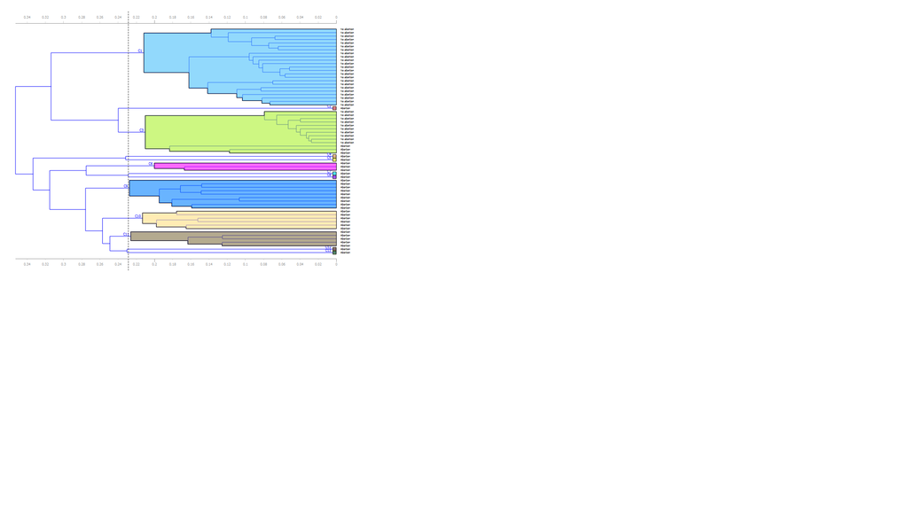

# Hierarchical Clustering Wed Apr 08 20, 12:52:11

**Linkage:** ward  
**Annotation:** category  
**Selection:** at 64.8 of height

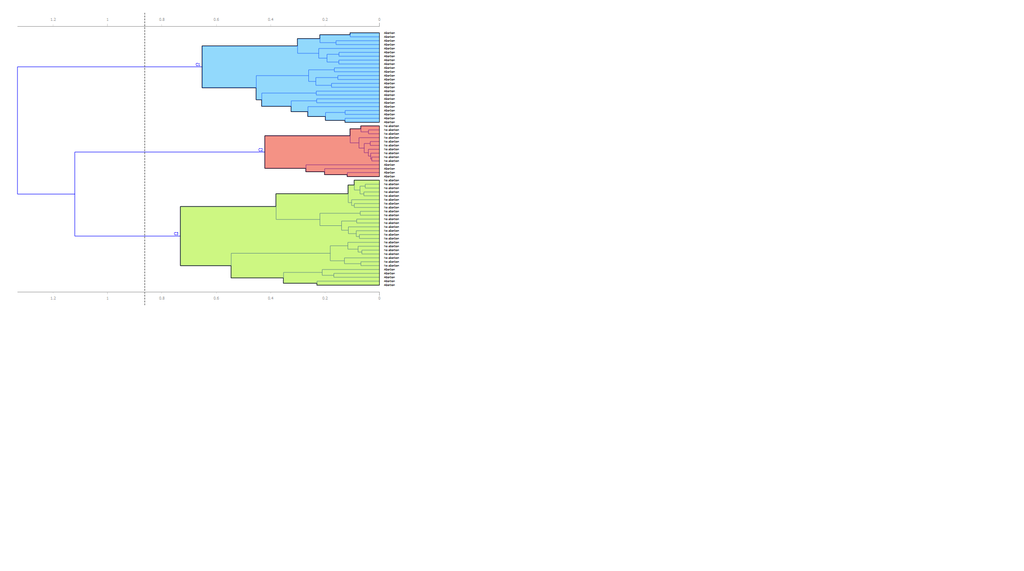

# Hierarchical Clustering Wed Apr 08 20, 12:54:52

**Linkage:** complete  
**Annotation:** category  
**Selection:** at 64.8 of height

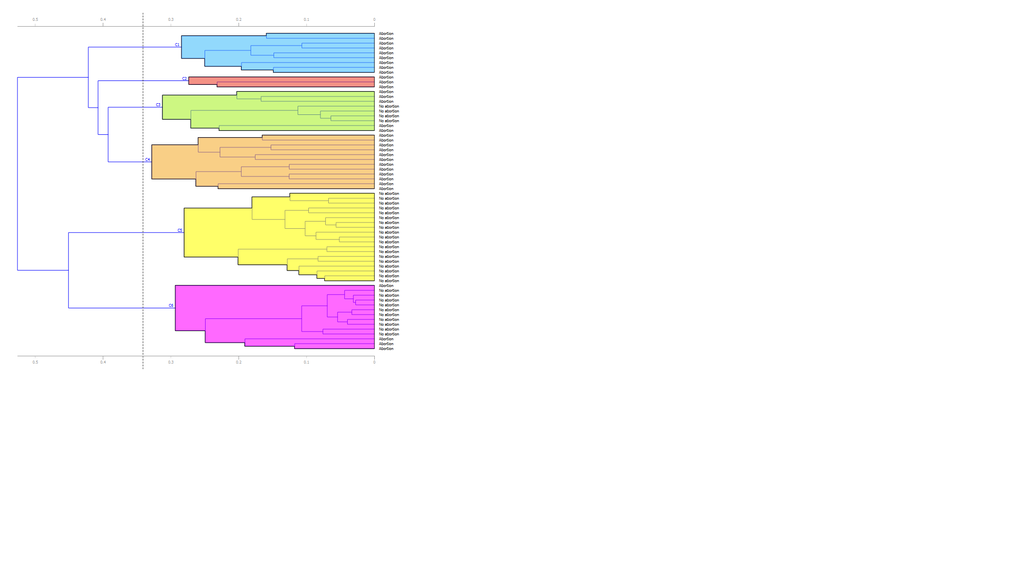